# Kompetensförsörjning i Dalarna

# 5 Hur väl fungerar arbetsmarknaden i Dalarna?

En väl fungerande arbetsmarknad kännetecknas bland annat av att många arbetar, att många arbetar med vad de är utbildade till och att det inte råder någon större brist på kompetens. En arbetsmarknad med dessa kännetecken kan sannolikt hantera såväl kriser i samhället, som de utmaningar som arbetsmarknaden ställs inför i framtiden.

## 5.1 Hur många arbetar?

Sysselsättningsgraden, det vill säga utsträckningen i vilken människor i arbetsför ålder (20-64 år) arbetar, skiljer sig framförallt åt mellan inrikes och utrikes födda. Sysselsättningsgraden bland utrikes födda är lägre än sysselsättningsgraden för inrikes födda i samtliga svenska län. Det finns även skillnader mellan kvinnor och män. För inrikes födda, det vänstra diagrammet nedan, är sysselsättningsgraden för båda könen ungefär lika hög. Variationen i sysselsättningsgrad mellan länen är även den ganska liten. För utrikes födda (det högra diagrammet nedan) är bilden annorlunda. Utrikes födda män har en högre sysselsättningsgrad än utrikes födda kvinnor i samtliga län förutom Norrbotten. I Dalarna var sysselsättningsgraden bland utrikes födda män ungefär 73 procent, vilket är ca 8 procentenheter mer än för utrikes födda kvinnor i Dalarna.

Något man dock måste ta hänsyn till när man analyserar sysselsättningsgrad bland utrikes födda är hur lång tid personerna har varit i Sverige, samt vilken utbildningsnivå de har. För en djupare diskussion runt detta, se Region Dalarnas rapport [“Kvinnor och män i Dalarna”](https://region-dalarna.github.io/kvinnor_man_i_Dalarna/)

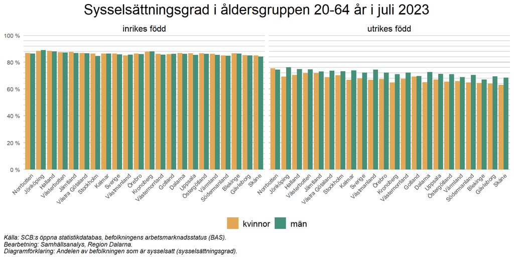

Vad gäller sysselsättningsgrad uppvisar kommunerna i Dalarna ett liknande mönster som länen på nationell nivå. Gruppen inrikes födda har en högre sysselsättningsgrad i samtliga kommuner i Dalarna jämfört med utrikes födda. Även här är sysselsättningsgraden för inrikes födda kvinnor och män ungefär lika hög. För utrikes födda är det däremot stora skillnader mellan kvinnor och män, men också mellan olika kommuner. I linje med den nationella bilden är sysselsättningsgraden högre för gruppen utrikes födda män än för utrikes födda kvinnor. Sysselsättningsgraden för utrikes födda män skiljer sig dock åt mellan kommuner där den högsta sysselsättningsgraden finns i Mora (ca 79 procent) och den lägsta i Avesta (ungefär 68 procent).

Skillnaderna mellan utrikes födda kvinnor och män är mer synlig mellan kommuner i Dalarna än när länen som helhet jämförs. Orsa har den högsta sysselsättningsgraden för gruppen utrikes födda kvinnor, runt 75 procent, och ligger klart över genomsnittet för Dalarnas län (knappt 65 procent). Samtidigt är sysselsättningsgraden i Borlänge kommun bland utrikes födda kvinnor bara ungefär 59 procent.

Värt att notera är att en del av skillnaden i utrikes föddas sysselsättningsgrad mellan kommunerna i Dalarna sannolikt kan förklaras av skillnader i antalet personer som invandrade under åren runt flyktingkrisen 2015. Exempelvis var Avesta, Ludvika och Hedemora de tre kommuner som hade högst invandring i förhållande till folkmängd under 2015, 2016 och 2017.

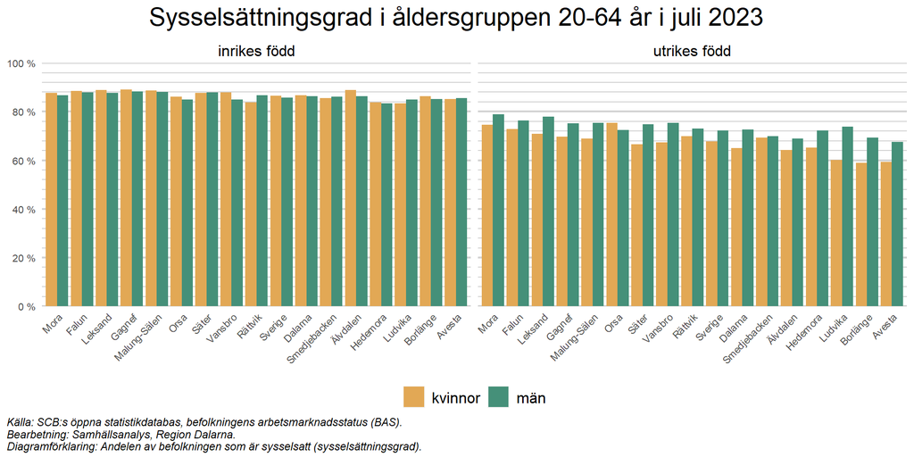

## 5.2 Matchning på arbetsmarknaden

Nivån av matchning på arbetsmarknaden mäter i hur stor utsträckning människor jobbar med vad de är utbildade till. Generellt tenderar olika typer av specialiserade eftergymnasiala utbildningar, exempelvis läkare och psykologer, ha hög matchning. Utbildar man sig till läkare är det väldigt hög sannolikhet att man även har det som yrke (närmare 100 procent). På andra sidan av spektrumet finns dels olika former av gymnasieutbildningar, dels eftergymnasiala utbildningar inom exempelvis humaniora och konst, där runt hälften jobbar med vad de är utbildade till. Rent generellt ligger matchninggraden på runt 71 procent i Sverige, där något fler kvinnor än män jobbar med vad de är utbildade till. Det finns vissa skillnader mellan länen, men dessa är relativt små. I Dalarna är matchningsgraden ca 69 procent, vilket är något sämre än riket som helhet.

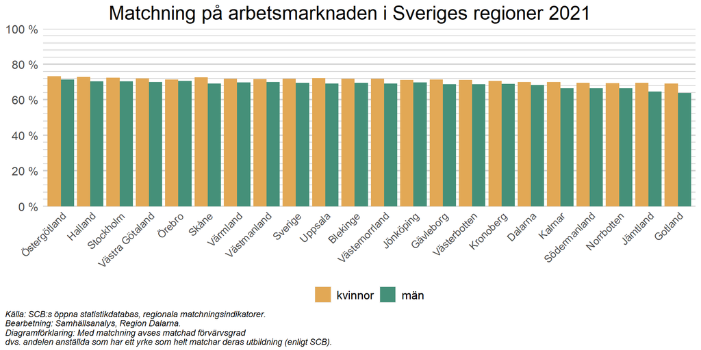

Matchningen på arbetsmarknaden tenderar att variera beroende på var man är född. I Dalarna har inrikes födda högst matchning med ungefär 70 procent för både kvinnor och män. Även personer födda inom EU har hög matchning (runt 66 procent). Lägst matchningsgrad har personer födda i Asien (ca 64 procent).

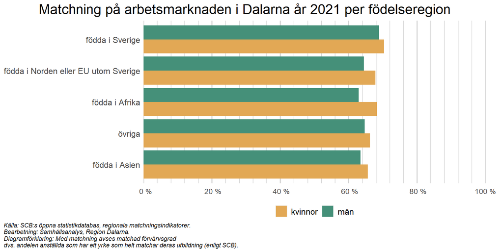

## 5.3 Brist på kompetens

Ytterligare en viktig aspekt av en regions arbetsmarknad är hur lätt det är för arbetsgivare att hitta arbetskraft. Bland Sveriges län varierar den upplevda bristen på arbetskraft relativt mycket. Lättast att hitta kompetens år 2023 har småföretag i Östergötlands län, där ungefär 20 procent av småföretagen uppger att de har brist på kompetens. Att jämföra med Norrbottens län, där ungefär 45 procent av småföretagen uppger att de har samma brist. I Dalarna upplever ungefär 41 procent av småföretagarna att de har svårt att hitta arbetskraft, vilket är en ökning med 13 procentenheter sedan undersökningen som gjordes 2020.

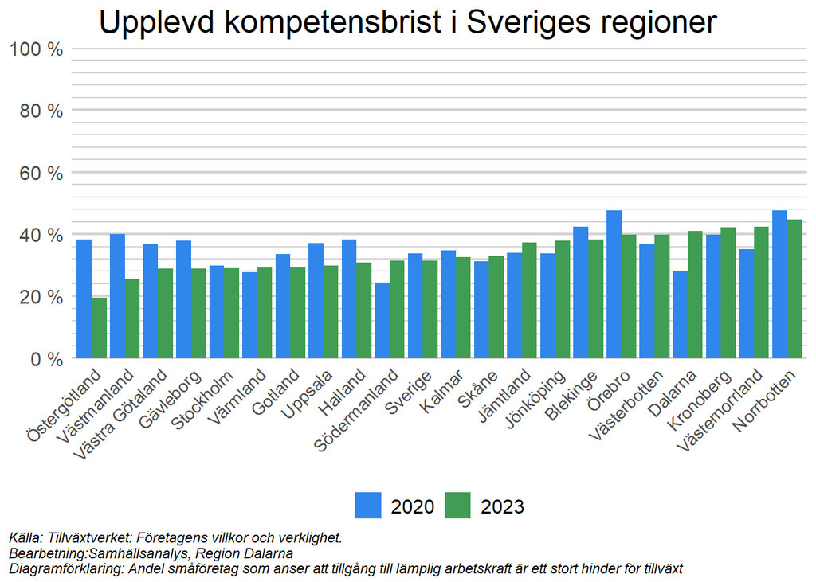

# 6 Utbildningsområden och prognoser

## Bygg

[figure not shown]

Figur 38

[figure not shown]

Figur 39

[figure not shown]

Figur 40

[figure not shown]

Figur 41

[figure not shown]

Figur 42

[figure not shown]

Figur 43

[^1]: https://www.scb.se/dokumentation/klassifikationer-och-standarder/standard-for-svensk-yrkesklassificering-ssyk/